# Covid_19_Analysis

Swapnil_Sethi

9/21/2021

## *Note: I am using tidyverse, and lubridate libraries for my analysis. If you have not installed these libraries earlier, then install them and then run this report.*

### INDEX

libraries  
SessionInfo  
Question of Interest Data Collection  
Read Covid Data  
Global Covid Data Transformation  
Read and Add Global Population Data  
US Covid Data Transformation  
add US states area data *(New)*  
Visualize Global Data *(New, Contains 2 visuals)*  
Visualize US Data  
Outliers in pop_density data *(new, determine outliers in population density)*  
Analyze the data  
US States Covid analysis with population density *(New, contains 1 visual with liner regression model)*  
Model the data [Biases]  
Conclusion

## libraries

```r
library(tidyverse)
library(lubridate)
```

## *See this session info for more insights on the packages I am using. If you are not able to knit the report then you might consider updating your packages to the below versions.*

[session information not shown]

## Question of Interest

Covid-19 has affected people’s lives in many ways all over the world. Today, through this analysis we will try to understand how Covid-19 has spread over time in different countries and will analyze the spread of Covid-19 in the United Kingdom. We will also go in depth to understand how it’s spread in the different US States.

## Data Collection

As you know, to do any analysis first we need to gather data. John Hopkins University has collected Covid-19 data from all over the world and published it in the GitHub repository for public use. We will use the same data for our analysis.

Let’s connect to GitHub repository

```r
## Get current Data from the four files.
url_in <- "https://raw.githubusercontent.com/CSSEGISandData/COVID-19/master/csse_covid_19_data/csse_covid_19_time_series/time_series_covid19_"
file_names <- c("confirmed_global.csv",
                    "deaths_global.csv",
                    "confirmed_US.csv",
                    "deaths_US.csv")
urls <- str_c(url_in,file_names)
```

## Read Covid data

Read the data and let’s took quick look at it.

```r
global_cases <- read_csv(urls[1], show_col_types = FALSE) #read Global cases data
global_deaths <- read_csv(urls[2], show_col_types = FALSE) #read Global deaths data
US_cases <- read_csv(urls[3], show_col_types = FALSE) #read US cases data
US_deaths <- read_csv(urls[4], show_col_types = FALSE) #read US deaths data
```

## Global Covid Data Transformation

After looking at global_cases and global_deaths, I would like to tidy those datasets and put each variable (date, cases, deaths) in its own column. Also, I don’t need Lat and Long for the analysis I am planning, so I will get rid of those and rename Region and State to be more R friendly.

```r
global_cases <- global_cases %>%
    pivot_longer(cols = -c(`Province/State`,
                           `Country/Region`, Lat, Long),
                 names_to = "date",
               values_to = "cases") %>%      #pivot date and cases columns
  select(-c(Lat,Long))                   #remove lat and long columns

global_deaths <- global_deaths %>%
    pivot_longer(cols = -c(`Province/State`,
                           `Country/Region`, Lat, Long),
                 names_to = "date",
               values_to = "deaths") %>%      #pivot date and death columns
  select(-c(Lat, Long))               #remove lat and long

global <- global_cases %>%
  full_join(global_deaths) %>%  #combine both global cases and global deaths in a single dataframe global
  rename(Country_Region = `Country/Region`,
         Province_State = `Province/State`) %>%    #rename columns
  mutate(date = mdy(date))    #change datatype of date column to date.
```

Now, let’s take look at a summary of the data to see if there are problems

```r
summary(global)
```

```
##  Province_State     Country_Region          date                cases
##  Length:174654      Length:174654      Min.   :2020-01-22   Min.   :       0
##  Class :character   Class :character   1st Qu.:2020-06-26   1st Qu.:     149
##  Mode  :character   Mode  :character   Median :2020-11-29   Median :    2478
##                                        Mean   :2020-11-29   Mean   :  303033
##                                        3rd Qu.:2021-05-05   3rd Qu.:   56848
##                                        Max.   :2021-10-08   Max.   :44290052
##      deaths
##  Min.   :     0.0
##  1st Qu.:     1.0
##  Median :    39.0
##  Mean   :  6922.8
##  3rd Qu.:   937.8
##  Max.   :712693.0
```

Everything looks good, except rows having min cases = 0

I don’t need rows with cases = 0 for my analysis, so I will get rid of rows with no cases

```r
global <- global %>% filter(cases > 0 )
```

## Read and Add Global Population Data

We notice that we don’t have population data for the world data. If we plan to do a comparative analysis between countries, we will want to add the population data to our global dataset.

Let’s add population data and a variable called Combined_Key that combines the Province_State with the Country_Region

```r
global <- global %>%
  unite("Combined_Key",
                 c(Province_State, Country_Region),
                                   sep = ", ",
                 na.rm = TRUE,
                 remove = FALSE)  #create a key column keeping original columns as it is.
```

First read population data

```r
uid_lookup_url <- "https://raw.githubusercontent.com/CSSEGISandData/COVID-19/master/csse_covid_19_data/UID_ISO_FIPS_LookUp_Table.csv"
uid <- read_csv(uid_lookup_url) %>%
  select(-c(Lat, Long_, Combined_Key, code3, iso2, iso3, Admin2)) #remove unnecessary columns
```

Add this population data to the global dataset.

```r
global <- global %>%
  left_join(uid, by = c("Province_State", "Country_Region")) %>% #add population data in global dataframe
  select(-c(UID, FIPS)) %>%
  select(Province_State, Country_Region, date,
         cases, deaths, Population,
         Combined_Key)
```

## US Covid Data Transformation

Now, let’s look at US data

```r
US_cases <- US_cases %>%
    pivot_longer(cols = -(UID:Combined_Key), #pivot data
                 names_to = "date",
                 values_to = "cases") %>%
    select(Admin2:cases) %>%
    mutate(date = mdy(date)) %>% #change datatype of date column
  select(-c(Lat, Long_))   #remove unnecessary columns

US_deaths <- US_deaths %>%
    pivot_longer(cols = -(UID:Population), #pivot data
                 names_to = "date",
                 values_to ="deaths") %>%
    select(Admin2:deaths) %>%
    mutate(date = mdy(date)) %>%  #change datatype of date column
 select(-c(Lat, Long_))  #remove unnecessary columns


US <- US_cases %>%
  full_join(US_deaths) #combine US cases and deaths data
```

Everything looks good, except rows having min cases = 0.

I don’t need rows with cases = 0 for my analysis, so I will get rid of rows with no cases.

```r
 US <- US %>%
  filter(cases > 0)
```

## add US states area data

For our analysis, we will need US States area data and we don’t have this data. Let’s read this data and add it to the US dataframe.

First, read the area data and then combines it with the US data on the Province_State

```r
area_lookup_url <- ("https://raw.githubusercontent.com/jakevdp/data-USstates/master/state-areas.csv")
area <- read_csv(area_lookup_url,show_col_types = FALSE) %>% mutate(Province_State = state) %>% select(-state)


US <- US %>%
  left_join(area, by = c("Province_State"))

US <- US %>% mutate(pop_density = Population / `area (sq. mi)`)
```

Summarize US data

```r
summary(US)
```

```
##     Admin2          Province_State     Country_Region     Combined_Key
##  Length:1795796     Length:1795796     Length:1795796     Length:1795796
##  Class :character   Class :character   Class :character   Class :character
##  Mode  :character   Mode  :character   Mode  :character   Mode  :character
##
##
##
##
##       date                cases           Population           deaths
##  Min.   :2020-01-22   Min.   :      1   Min.   :       0   Min.   :    0.0
##  1st Qu.:2020-08-19   1st Qu.:    183   1st Qu.:   11284   1st Qu.:    2.0
##  Median :2021-01-05   Median :   1029   Median :   26729   Median :   19.0
##  Mean   :2021-01-03   Mean   :   6091   Mean   :  106620   Mean   :  114.8
##  3rd Qu.:2021-05-23   3rd Qu.:   3564   3rd Qu.:   69872   3rd Qu.:   67.0
##  Max.   :2021-10-08   Max.   :1468634   Max.   :10039107   Max.   :26284.0
##
##  area (sq. mi)     pop_density
##  Min.   :    68   Min.   :    0.000
##  1st Qu.: 44828   1st Qu.:    0.157
##  Median : 59441   Median :    0.451
##  Mean   : 83020   Mean   :    6.405
##  3rd Qu.: 83574   3rd Qu.:    1.371
##  Max.   :656425   Max.   :10378.662
##  NA's   :2848     NA's   :2848
```

## Visualize Global Data

#### Let’s look at the total number of cases over time and the total deaths over time for world as a whole and for a given country

```r
global_by_country <- global %>%
  group_by(Province_State, Country_Region, date, Combined_Key) %>%
  summarize(cases = sum(cases), deaths = sum(deaths),
            Population = sum(Population)) %>%
  mutate(deaths_per_mill = deaths *1000000 / Population) %>%
  mutate(cases_per_mill = cases *1000000 / Population) %>%
  select( Country_Region, date,
         cases, deaths, deaths_per_mill,cases_per_mill, Population) %>%
  ungroup()
summary(global_by_country)
```

```
##  Province_State     Country_Region          date                cases
##  Length:158603      Length:158603      Min.   :2020-01-22   Min.   :       1
##  Class :character   Class :character   1st Qu.:2020-07-28   1st Qu.:     378
##  Mode  :character   Mode  :character   Median :2020-12-24   Median :    4558
##                                        Mean   :2020-12-21   Mean   :  333700
##                                        3rd Qu.:2021-05-18   3rd Qu.:   74496
##                                        Max.   :2021-10-08   Max.   :44290052
##
##      deaths       deaths_per_mill    cases_per_mill       Population
##  Min.   :     0   Min.   :   0.000   Min.   :     0.0   Min.   :8.090e+02
##  1st Qu.:     3   1st Qu.:   0.345   1st Qu.:   125.4   1st Qu.:8.964e+05
##  Median :    68   Median :  24.359   Median :  1588.4   Median :7.276e+06
##  Mean   :  7623   Mean   : 269.542   Mean   : 15496.3   Mean   :2.980e+07
##  3rd Qu.:  1322   3rd Qu.: 247.057   3rd Qu.: 15889.1   3rd Qu.:3.102e+07
##  Max.   :712693   Max.   :6054.620   Max.   :220927.4   Max.   :1.380e+09
##                   NA's   :2214       NA's   :2214       NA's   :2214
```

Let’s create a new dataframe with aggregated data at the date level ie. e remove the country level granularity

```r
global_totals <- global_by_country %>%
  group_by( date) %>%
   summarize(cases = sum(cases), deaths = sum(deaths),
            Population = sum(Population)) %>%
  mutate(deaths_per_mill = deaths *1000000 / Population) %>% #calculate deaths per thousand
  mutate(cases_per_mill = cases *1000000 / Population)%>%  #calculate cases per thousand
  select( date,
         cases, deaths, deaths_per_mill, cases_per_mill) %>%  #select required columns
  ungroup()
```

## Analyze global cases and deaths over time

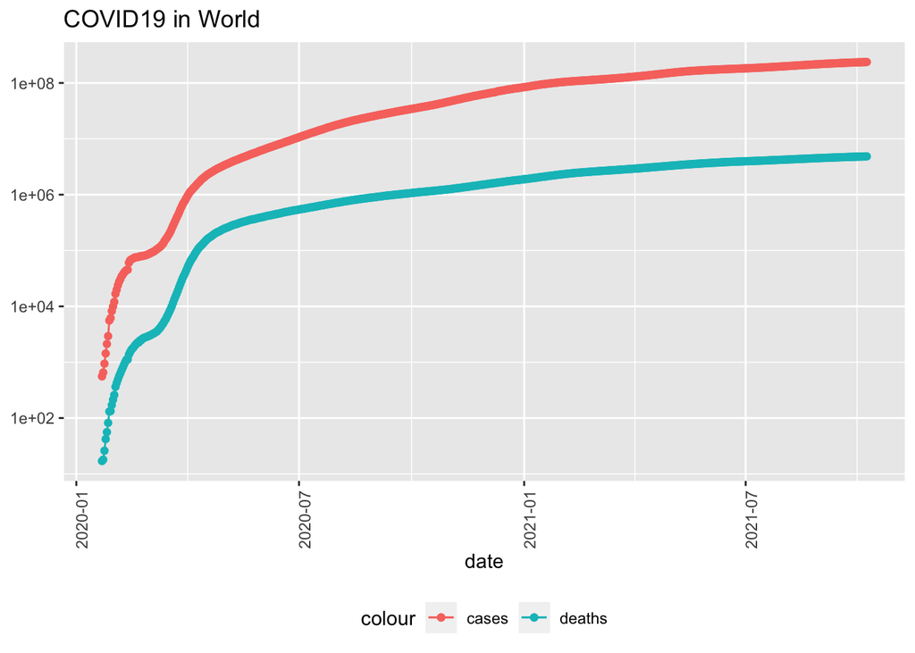

```r
global_totals %>%
  filter(cases > 0) %>%
  ggplot(aes(x = date, y = cases)) +
    geom_line(aes(color = "cases")) +
  geom_point(aes(color = "cases")) +
  geom_line(aes(y = deaths, color = "deaths")) +
  geom_point(aes(y = deaths, color = "deaths")) +
    scale_y_log10() +
    theme(legend.position="bottom",
          axis.text.x = element_text(angle = 90)) +
  labs(title = "COVID19 in World", y= NULL)
```

##United Kingdom total cases and total deaths over time

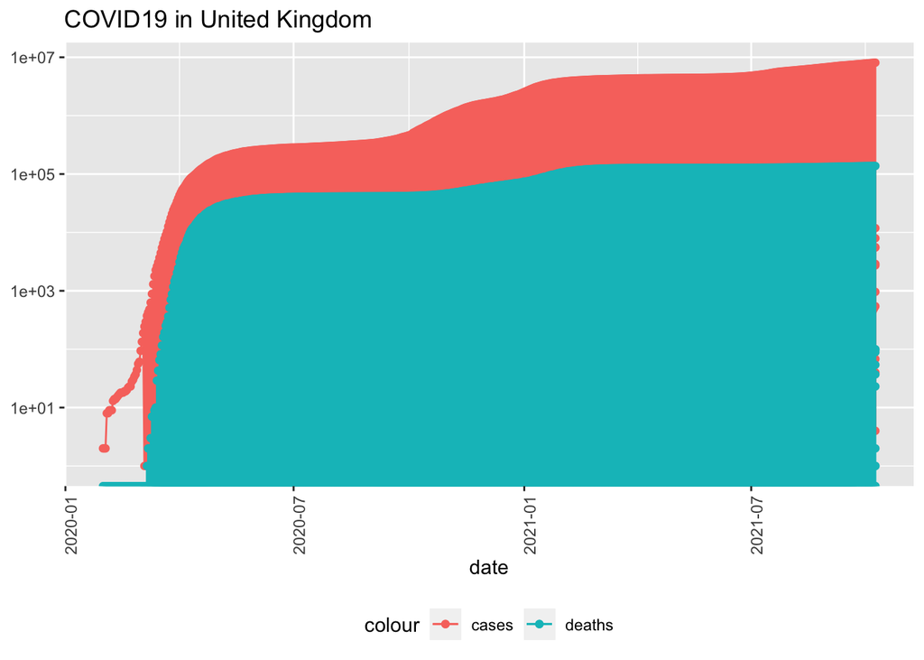

```r
country <- "United Kingdom"
global_by_country %>%
  filter(Country_Region == country) %>%
  filter(cases > 0) %>%
  ggplot(aes(x = date, y = cases)) +
  geom_line(aes(color = "cases")) +
  geom_point(aes(color = "cases")) +
  geom_line(aes(y = deaths, color = "deaths")) +
  geom_point(aes(y = deaths, color = "deaths")) +
    scale_y_log10() +
    theme(legend.position="bottom",
          axis.text.x = element_text(angle = 90)) +
  labs(title = str_c("COVID19 in ", country), y= NULL)
```

## Visualize US Data

let’s summarize US data first and look for anomalies

```r
summary(US)
```

```
##     Admin2          Province_State     Country_Region     Combined_Key
##  Length:1795796     Length:1795796     Length:1795796     Length:1795796
##  Class :character   Class :character   Class :character   Class :character
##  Mode  :character   Mode  :character   Mode  :character   Mode  :character
##
##
##
##
##       date                cases           Population           deaths
##  Min.   :2020-01-22   Min.   :      1   Min.   :       0   Min.   :    0.0
##  1st Qu.:2020-08-19   1st Qu.:    183   1st Qu.:   11284   1st Qu.:    2.0
##  Median :2021-01-05   Median :   1029   Median :   26729   Median :   19.0
##  Mean   :2021-01-03   Mean   :   6091   Mean   :  106620   Mean   :  114.8
##  3rd Qu.:2021-05-23   3rd Qu.:   3564   3rd Qu.:   69872   3rd Qu.:   67.0
##  Max.   :2021-10-08   Max.   :1468634   Max.   :10039107   Max.   :26284.0
##
##  area (sq. mi)     pop_density
##  Min.   :    68   Min.   :    0.000
##  1st Qu.: 44828   1st Qu.:    0.157
##  Median : 59441   Median :    0.451
##  Mean   : 83020   Mean   :    6.405
##  3rd Qu.: 83574   3rd Qu.:    1.371
##  Max.   :656425   Max.   :10378.662
##  NA's   :2848     NA's   :2848
```

## Outliers in pop_density data

As you can see here, for population density mean is far greater than 3rd quartile, How is this possible? let’s figure it out.

Let’s take a look at top 10 state with higher population density.

```r
US %>% group_by(Province_State) %>% summarize(pop_density = mean(pop_density)) %>%
  slice_max(pop_density, n = 10) %>% select(Province_State, Province_State, pop_density)
```

| Province_State | pop_density |
| --- | --- |
| District of Columbia | 10378.66176 |
| Delaware | 126.45938 |
| Rhode Island | 115.95974 |
| Connecticut | 71.87948 |
| Massachusetts | 47.03364 |
| New Jersey | 46.54585 |
| Hawaii | 25.61615 |
| Maryland | 20.49582 |
| Puerto Rico | 13.40836 |
| New Hampshire | 13.38000 |

see “District of Columbia” has population density 10378.66176, which is too higher than rest of the state, hence it will create a bias in our analysis.. let’s get rid of it..

```r
US <- US %>% filter(Province_State!= "District of Columbia")

summary(US)
```

```
##     Admin2          Province_State     Country_Region     Combined_Key
##  Length:1795224     Length:1795224     Length:1795224     Length:1795224
##  Class :character   Class :character   Class :character   Class :character
##  Mode  :character   Mode  :character   Mode  :character   Mode  :character
##
##
##
##
##       date                cases           Population           deaths
##  Min.   :2020-01-22   Min.   :      1   Min.   :       0   Min.   :    0.0
##  1st Qu.:2020-08-19   1st Qu.:    183   1st Qu.:   11284   1st Qu.:    2.0
##  Median :2021-01-05   Median :   1028   Median :   26720   Median :   19.0
##  Mean   :2021-01-03   Mean   :   6084   Mean   :  106429   Mean   :  114.6
##  3rd Qu.:2021-05-23   3rd Qu.:   3560   3rd Qu.:   69830   3rd Qu.:   67.0
##  Max.   :2021-10-08   Max.   :1468634   Max.   :10039107   Max.   :26284.0
##
##  area (sq. mi)     pop_density
##  Min.   :  1545   Min.   :  0.0000
##  1st Qu.: 44828   1st Qu.:  0.1570
##  Median : 59441   Median :  0.4495
##  Mean   : 83047   Mean   :  3.0950
##  3rd Qu.: 83574   3rd Qu.:  1.3707
##  Max.   :656425   Max.   :413.5476
##  NA's   :2848     NA's   :2848
```

#### Let’s look at the total number of cases over time and the total deaths over time for the US as a whole and for a given state.

```r
US_by_state <- US %>%
  group_by(Province_State, Country_Region, date) %>%
  summarize(cases = sum(cases), deaths = sum(deaths),
            Population = sum(Population), pop_density= sum(pop_density)) %>%
  mutate(deaths_per_mill = deaths *1000000 / Population) %>%
  mutate(cases_per_mill = cases *1000000 / Population) %>%
  select(Province_State, Country_Region, date,
         cases, deaths, deaths_per_mill,cases_per_mill, Population, pop_density) %>%
  ungroup()
summary(US_by_state)
```

```
##  Province_State     Country_Region          date                cases
##  Length:32641       Length:32641       Min.   :2020-01-22   Min.   :      1
##  Class :character   Class :character   1st Qu.:2020-07-28   1st Qu.:  13434
##  Mode  :character   Mode  :character   Median :2020-12-21   Median : 111215
##                                        Mean   :2020-12-20   Mean   : 334597
##                                        3rd Qu.:2021-05-16   3rd Qu.: 425261
##                                        Max.   :2021-10-08   Max.   :4771626
##
##      deaths      deaths_per_mill  cases_per_mill        Population
##  Min.   :    0   Min.   :   0.0   Min.   :     0.15   Min.   :       0
##  1st Qu.:  284   1st Qu.: 196.6   1st Qu.:  9020.13   1st Qu.: 1344212
##  Median : 2084   Median : 738.8   Median : 44838.58   Median : 3754939
##  Mean   : 6304   Mean   :   Inf   Mean   :      Inf   Mean   : 5853486
##  3rd Qu.: 7492   3rd Qu.:1656.2   3rd Qu.:102193.81   3rd Qu.: 6863772
##  Max.   :69966   Max.   :   Inf   Max.   :      Inf   Max.   :39512223
##                  NA's   :593
##   pop_density
##  Min.   :   0.00
##  1st Qu.:  42.86
##  Median :  93.53
##  Mean   : 186.20
##  3rd Qu.: 199.57
##  Max.   :1068.26
##  NA's   :2848
```

#### We want to visualize total cases and deaths in US, for that we will create new dataframe with aggregate data at date level i.e. we shall get rid of the state granularity of data.

```r
US_totals <- US_by_state %>%
  group_by(Country_Region, date) %>%
   summarize(cases = sum(cases), deaths = sum(deaths),
            Population = sum(Population)) %>%
  mutate(deaths_per_mill = deaths *1000000 / Population) %>%
  select(Country_Region, date,
         cases, deaths, deaths_per_mill, Population) %>%
  ungroup()
```

#### Now,let’s visualize US total cases and deaths over time

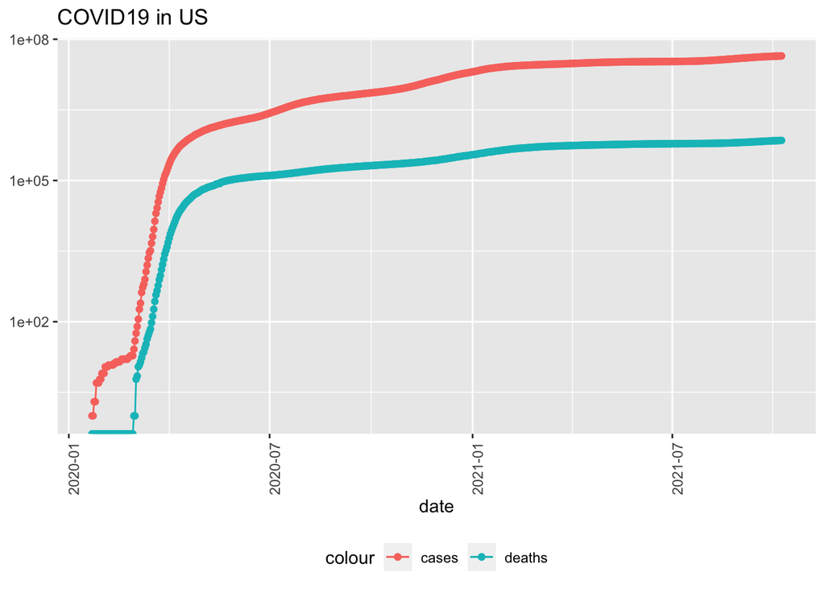

```r
US_totals %>%
  filter(cases > 0) %>%
  ggplot(aes(x = date, y = cases)) +
    geom_line(aes(color = "cases")) +
  geom_point(aes(color = "cases")) +
  geom_line(aes(y = deaths, color = "deaths")) +
  geom_point(aes(y = deaths, color = "deaths")) +
    scale_y_log10() +
    theme(legend.position="bottom",
          axis.text.x = element_text(angle = 90)) +
  labs(title = "COVID19 in US", y= NULL)
```

#### New York state total cases and total deaths over time

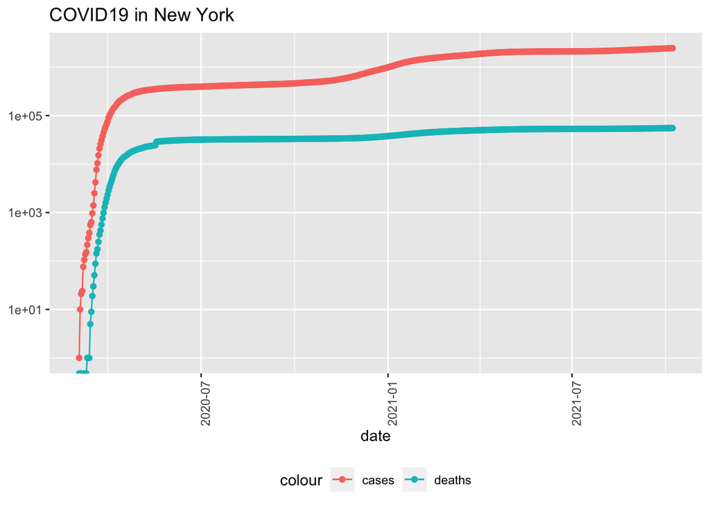

```r
state <- "New York"
US_by_state %>%
  filter(Province_State == state) %>%
  filter(cases > 0) %>%
  ggplot(aes(x = date, y = cases)) +
    geom_line(aes(color = "cases")) +
  geom_point(aes(color = "cases")) +
  geom_line(aes(y = deaths, color = "deaths")) +
  geom_point(aes(y = deaths, color = "deaths")) +
    scale_y_log10() +
    theme(legend.position="bottom",
          axis.text.x = element_text(angle = 90)) +
  labs(title = str_c("COVID19 in ", state), y= NULL)
```

## Analyze the data

So our graph looks like COVID has leveled off. Is that true? Look at the number of new cases and deaths per day.

```r
US_by_state <- US_by_state %>%
  mutate(new_cases = cases - lag(cases),
  new_deaths = deaths - lag(deaths))

US_totals <- US_totals %>%
  mutate(new_cases = cases - lag(cases),
  new_deaths = deaths - lag(deaths))
```

#### *Visualize these to see if that raises new questions*

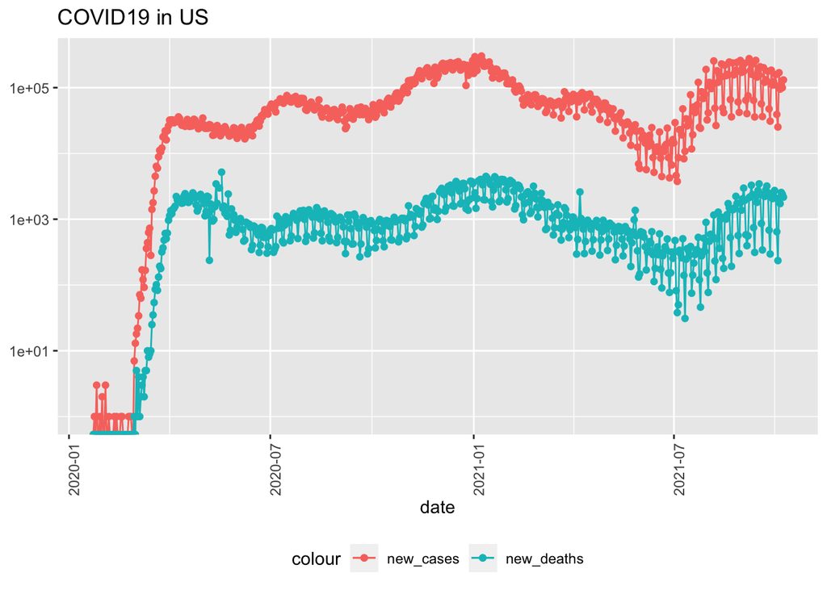

```r
US_totals %>%
  ggplot(aes(x = date, y = new_cases)) +
    geom_line(aes(color = "new_cases")) +
  geom_point(aes(color = "new_cases")) +
  geom_line(aes(y = new_deaths, color = "new_deaths")) +
  geom_point(aes(y = new_deaths, color = "new_deaths")) +
    scale_y_log10() +
    theme(legend.position="bottom",
          axis.text.x = element_text(angle = 90)) +
  labs(title = "COVID19 in US", y= NULL)
```

Plot a state

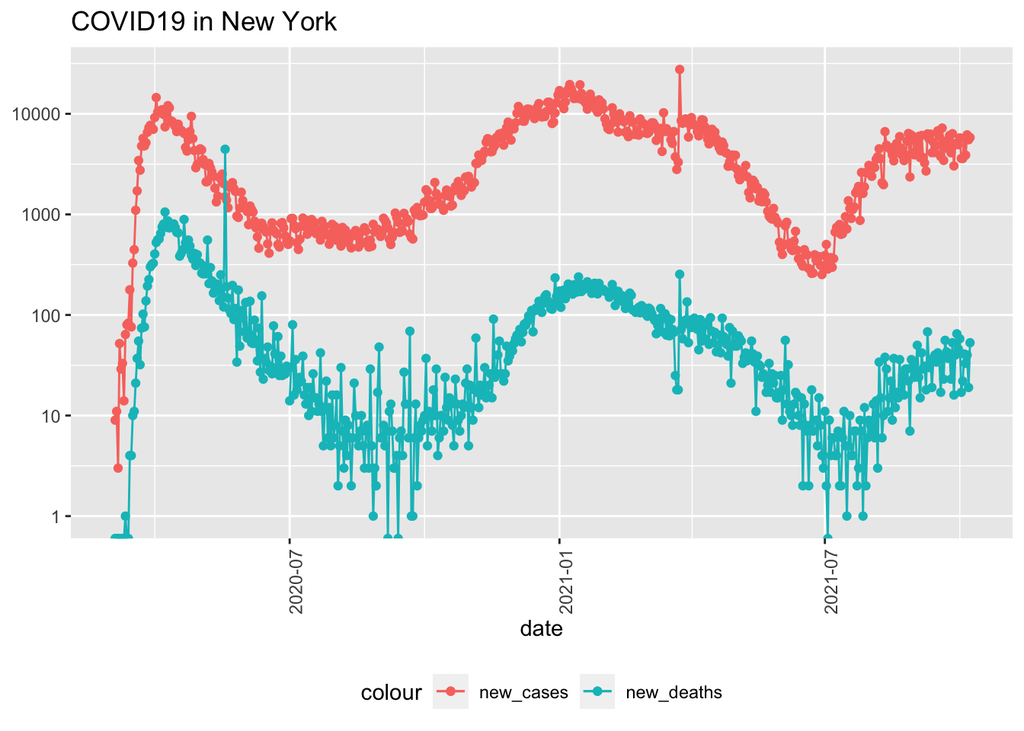

```r
state <- "New York"
US_by_state %>%
  filter(Province_State == state) %>%
  ggplot(aes(x = date, y = new_cases)) +
    geom_line(aes(color = "new_cases")) +
  geom_point(aes(color = "new_cases")) +
  geom_line(aes(y = new_deaths, color = "new_deaths")) +
  geom_point(aes(y = new_deaths, color = "new_deaths")) +
    scale_y_log10() +
    theme(legend.position="bottom",
          axis.text.x = element_text(angle = 90)) +
  labs(title = str_c("COVID19 in ", state), y= NULL)
```

worst and best states? How to measure this? Perhaps look at case rates and death rates per 1000 people?

```r
US_state_totals <- US_by_state %>%
  group_by(Province_State) %>%
  summarize(deaths = max(deaths), cases = max(cases),
            population = max(Population), pop_density =max(pop_density),
            cases_per_thou = 1000* cases / population,
            deaths_per_thou = 1000 * deaths / population) %>%
  filter(cases > 0, population > 0)
```

States with minimum death rates per thousand

```r
US_state_totals %>%
  slice_min(deaths_per_thou, n = 10)
```

| Province_State | deaths | cases | population | pop_density | cases_per_thou | deaths_per_thou |
| --- | --- | --- | --- | --- | --- | --- |
| American Samoa | 0 | 3 | 55641 | NA | 0.05391708 | 0.00000000 |
| Northern Mariana Islands | 2 | 273 | 55144 | NA | 4.95067460 | 0.03626868 |
| Vermont | 332 | 35204 | 623989 | 64.89745 | 56.41766121 | 0.53206066 |
| Hawaii | 833 | 81087 | 1415872 | 129.51628 | 57.27000746 | 0.58833002 |
| Virgin Islands | 73 | 6925 | 107268 | NA | 64.55792967 | 0.68053846 |
| Maine | 1070 | 94348 | 1344212 | 37.98604 | 70.18833339 | 0.79600539 |
| Alaska | 592 | 121348 | 728809 | 1.11027 | 166.50178579 | 0.81228415 |
| Puerto Rico | 3187 | 182790 | 3754939 | 1068.26145 | 48.67988535 | 0.84874881 |
| Oregon | 3982 | 341113 | 4217737 | 42.86928 | 80.87583460 | 0.94410818 |
| Washington | 8022 | 677995 | 7614893 | 106.79625 | 89.03539419 | 1.05346195 |

States with maximum death rates per thousand

```r
US_state_totals %>%
  slice_max(deaths_per_thou, n = 10)
```

| Province_State | deaths | cases | population | pop_density | cases_per_thou | deaths_per_thou |
| --- | --- | --- | --- | --- | --- | --- |
| Mississippi | 9811 | 494271 | 2976149 | 61.44752 | 166.0774 | 3.296542 |
| New Jersey | 27570 | 1168312 | 8882190 | 1018.36620 | 131.5342 | 3.103964 |
| Louisiana | 14173 | 747329 | 4648794 | 89.67062 | 160.7576 | 3.048748 |
| Alabama | 14756 | 806560 | 4903185 | 93.53118 | 164.4972 | 3.009472 |
| New York | 55342 | 2466780 | 19453561 | 357.10989 | 126.8035 | 2.844826 |
| Arizona | 20319 | 1114061 | 7278717 | 63.84503 | 153.0573 | 2.791563 |
| Massachusetts | 18746 | 823485 | 6863772 | 650.28631 | 119.9756 | 2.731151 |
| Rhode Island | 2854 | 174570 | 1059361 | 685.67055 | 164.7880 | 2.694077 |
| Florida | 56667 | 3645290 | 21477737 | 326.61786 | 169.7241 | 2.638406 |
| Arkansas | 7810 | 501518 | 3017804 | 56.74484 | 166.1864 | 2.587975 |

## US States Covid analysis with population density

Let’s see how the Deaths and cases are correlated in different US states as per population density

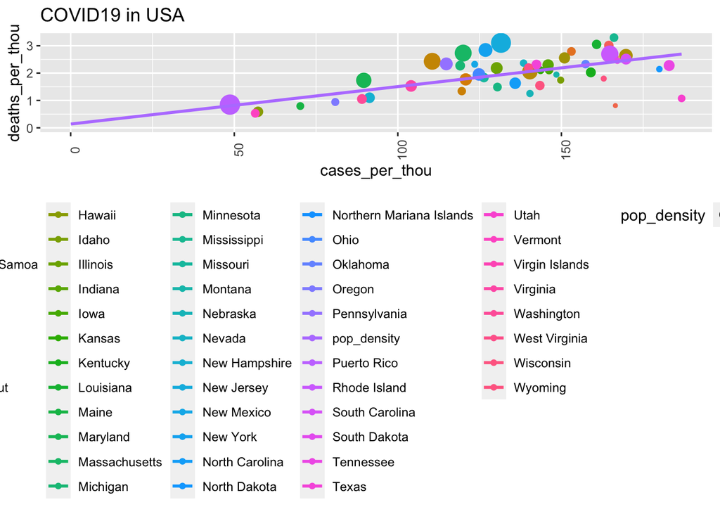

```r
state <- "District of Columbia"
(US_state_totals %>%
  filter(Province_State != state) %>%
  ggplot( aes(x = cases_per_thou , y = deaths_per_thou)) +
  geom_point(aes(size = pop_density ,  color = Province_State)) +
    geom_smooth(aes(color ="pop_density"),method="lm",se = FALSE)+
    theme(legend.position="bottom",
          axis.text.x = element_text(angle = 90)) +
  labs(title = str_c("COVID19 in USA")))
```

But, wait a sec, Have you observed Puerto Rico, it is one of the highest populated state, but have very low cases and death rate than other state.

let’s analyze Pureto Rico state to see what’s going on there.

```r
US_state_totals %>% filter(Province_State == "Puerto Rico")
```

| Province_State | deaths | cases | population | pop_density | cases_per_thou | deaths_per_thou |
| --- | --- | --- | --- | --- | --- | --- |
| Puerto Rico | 3187 | 182790 | 3754939 | 1068.261 | 48.67989 | 0.8487488 |

Everything looks okay on aggregate level. let’s analyze it in more detail at daily level

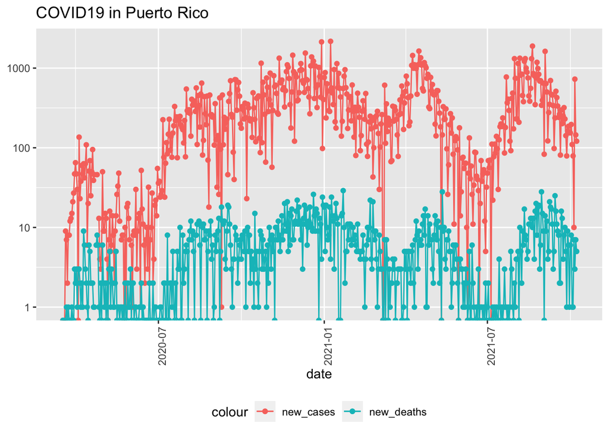

```r
state <- "Puerto Rico"
(US_by_state %>%
  filter(Province_State == state) %>%
  ggplot(aes(x = date, y = new_cases)) +
    geom_line(aes(color = "new_cases")) +
  geom_point(aes(color = "new_cases")) +
  geom_line(aes(y = new_deaths, color = "new_deaths")) +
  geom_point(aes(y = new_deaths, color = "new_deaths")) +
    scale_y_log10() +
    theme(legend.position="bottom",
          axis.text.x = element_text(angle = 90)) +
  labs(title = str_c("COVID19 in ", state), y= NULL))
```

Everything looks good in analysis we have done. Could be some other external factors affected the numbers, or Puerto Rico did something different than other states to control spread of Covid-19. But currently, we do not have more attribute to analyze these external factors.

## Model the data

We might need to introduce more variables here to build a model. Which do you want to consider? Population density, extent of lock down, political affiliation, climate of the area? When you determine the factors you want to try, add that data to your dataset, and then visualize and model and see if your variable has a statistically significant effect.

Let’s regress the deeaths per thousand on cases per thousand

```r
mod <- lm(deaths_per_thou ~ cases_per_thou, data = US_state_totals)
summary(mod)
```

```
##
## Call:
## lm(formula = deaths_per_thou ~ cases_per_thou, data = US_state_totals)
##
## Residuals:
##      Min       1Q   Median       3Q      Max
## -1.61934 -0.31874 -0.00861  0.31611  1.16539
##
## Coefficients:
##                Estimate Std. Error t value Pr(>|t|)
## (Intercept)     0.13855    0.23929   0.579    0.565
## cases_per_thou  0.01368    0.00179   7.647 4.11e-10 ***
## ---
## Signif. codes:  0 '***' 0.001 '**' 0.01 '*' 0.05 '.' 0.1 ' ' 1
##
## Residual standard error: 0.5472 on 53 degrees of freedom
## Multiple R-squared:  0.5246, Adjusted R-squared:  0.5156
## F-statistic: 58.48 on 1 and 53 DF,  p-value: 4.107e-10
```

look at the state with minimum cases per thousand

```r
US_state_totals %>% slice_min(cases_per_thou)
```

| Province_State | deaths | cases | population | pop_density | cases_per_thou | deaths_per_thou |
| --- | --- | --- | --- | --- | --- | --- |
| American Samoa | 0 | 3 | 55641 | NA | 0.05391708 | 0 |

look at the state with maximum cases per thousand

```r
US_state_totals %>% slice_max(cases_per_thou)
```

| Province_State | deaths | cases | population | pop_density | cases_per_thou | deaths_per_thou |
| --- | --- | --- | --- | --- | --- | --- |
| Utah | 2994 | 520190 | 2785478 | 32.80738 | 186.7507 | 1.07486 |

let’s try to predict number of deaths wrt cases

```r
x_grid <- seq(1, 151)
new_df <- tibble(cases_per_thou = x_grid)
US_state_totals %>% mutate(pred = predict(mod))
```

| Province_State | deaths | cases | population | pop_density | cases_per_thou | deaths_per_thou | pred |
| --- | --- | --- | --- | --- | --- | --- | --- |
| Alabama | 14756 | 806560 | 4903185 | 93.531179 | 164.49715848 | 3.00947241 | 2.3896660 |
| Alaska | 592 | 121348 | 728809 | 1.110270 | 166.50178579 | 0.81228415 | 2.4170990 |
| American Samoa | 0 | 3 | 55641 | NA | 0.05391708 | 0.00000000 | 0.1392892 |
| Arizona | 20319 | 1114061 | 7278717 | 63.845034 | 153.05733140 | 2.79156340 | 2.2331140 |
| Arkansas | 7810 | 501518 | 3017804 | 56.744838 | 166.18640574 | 2.58797457 | 2.4127830 |
| California | 69966 | 4771626 | 39512223 | 241.359398 | 120.76328887 | 1.77074320 | 1.7911757 |
| Colorado | 7733 | 688465 | 5758736 | 55.319270 | 119.55140850 | 1.34282940 | 1.7745913 |
| Connecticut | 8667 | 394008 | 3565287 | 643.089286 | 110.51228134 | 2.43094034 | 1.6508925 |
| Delaware | 1997 | 136682 | 973764 | 498.343910 | 140.36460580 | 2.05080492 | 2.0594163 |
| Florida | 56667 | 3645290 | 21477737 | 326.617856 | 169.72411945 | 2.63840646 | 2.4611960 |

[output cut: 45 more lines]

let’s visualize it

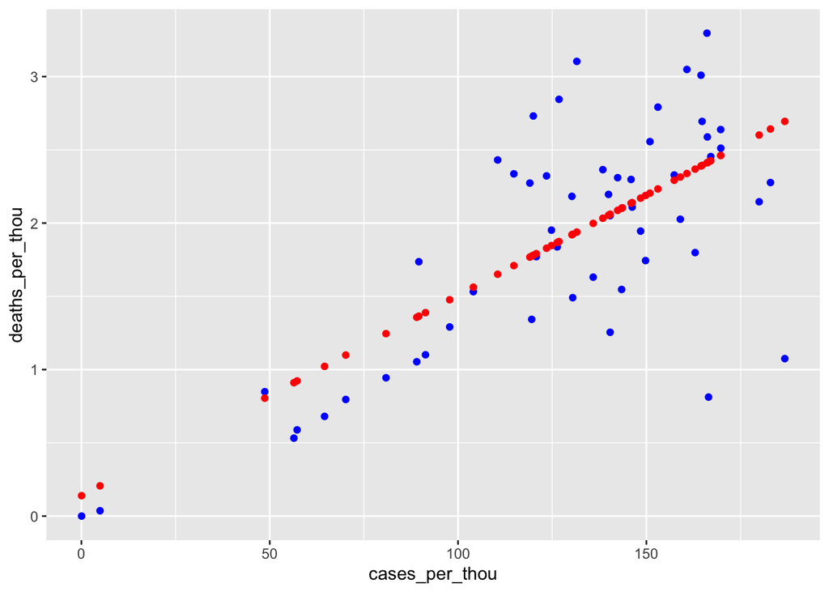

```r
US_tot_w_pred <- US_state_totals %>% mutate(pred = predict(mod))
US_tot_w_pred %>% ggplot() +
geom_point(aes(x = cases_per_thou, y = deaths_per_thou), color = "blue") +
geom_point(aes(x = cases_per_thou, y = pred), color = "red")
```

## Biases

Possible Sources of biases

#### 1. Data Collection Bias

In n different ways data collection bias can occur. Some of them I am listing here: 1. people with covid not getting tested 2. possible multiple test for a person 3. Nursing house deaths not counted 4. How to count a death as a covid 5. different data from different places 6. False positive and false negative results

#### 2. Algorithm Selection Bias

We are linearly regressing Covid deaths with the Covid cases, due to time limit. But linear regression algorithm is not best in our case.

#### 3. Result interpretation bias

Some doctors may analyze Pneumonia as a Covid or vice versa This is one example of result interpretation bias.